# SOC-GA 2332 Intro to Stats Lab 5 Solution

Di Zhou

3/5/2021

### Part 1 Exercise

1. Simulate the data with the same relationship as specified above, only **changing the residual term from having a sd = 10 to sd = 50**. Follow the steps demonstrated above, create a dataframe and fit an OLS model to your simulated data. Create a scatterplot of your data and post the plot to Slack. *Note:* Remember to `set.seed()`!

```r
set.seed(1234)
# Simulate IV (edu level)
edu2 <- rpois(300, lambda = 6) #rpois: Random Poisson Distribution with parameter lamda
# Simulate DV
earn2 <- 10 + 6*edu2 + rnorm(300, 0, 50) # add a random error using rnorm()

# Combine dataframe
df_exercise <- tibble(x_edu = edu2, y_earn = earn2)

# Fit model
m_simu_exercise <- lm(y_earn ~ x_edu, data = df_exercise)
summary(m_simu_exercise)
```

```
##
## Call:
## lm(formula = y_earn ~ x_edu, data = df_exercise)
##
## Residuals:
##     Min      1Q  Median      3Q     Max
## -167.42  -32.25   -0.62   33.37  146.08
##
## Coefficients:
##             Estimate Std. Error t value Pr(>|t|)
## (Intercept)   -1.402      7.839  -0.179    0.858
## x_edu          8.255      1.222   6.758 7.38e-11 ***
## ---
## Signif. codes:  0 '***' 0.001 '**' 0.01 '*' 0.05 '.' 0.1 ' ' 1
##
## Residual standard error: 51.35 on 298 degrees of freedom
## Multiple R-squared:  0.1329, Adjusted R-squared:   0.13
## F-statistic: 45.66 on 1 and 298 DF,  p-value: 7.38e-11
```

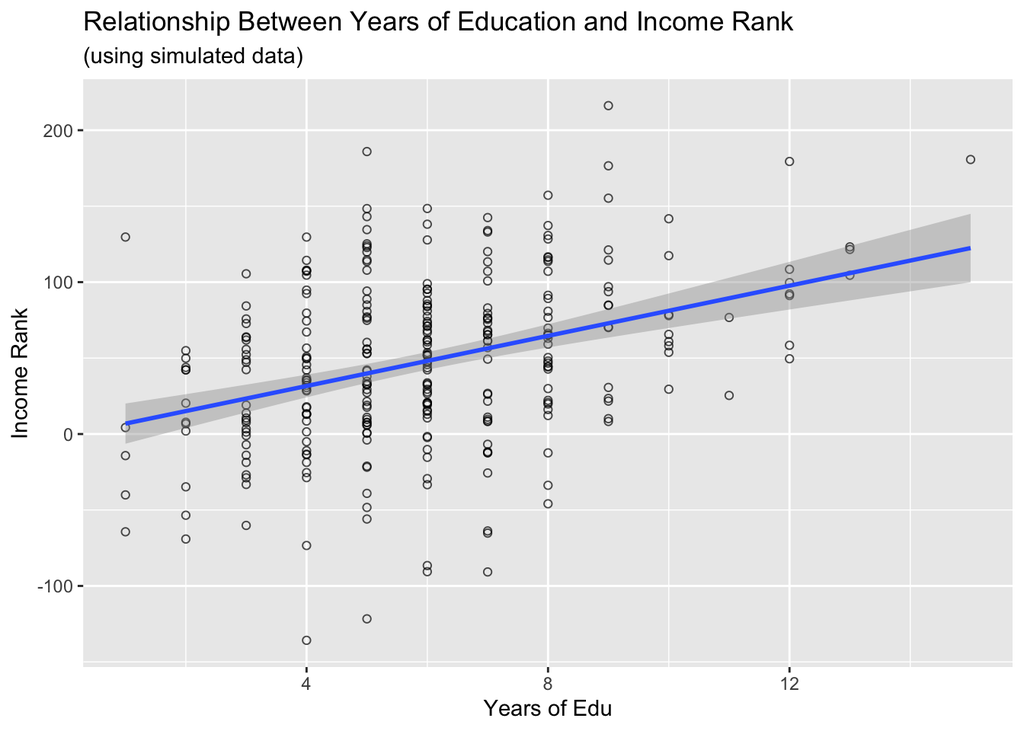

```r
# Scatterplot
df_exercise %>%
  ggplot(aes(x = x_edu, y = y_earn)) +
  geom_point(shape = 1, alpha = 0.7) +
  geom_smooth(method = "lm") +
  labs(title = "Relationship Between Years of Education and Income Rank",
       subtitle = "(using simulated data)",
       x = "Years of Edu",
       y = "Income Rank")
```

2. Then, using the formula we have learned in the lecture, hand-code the following statistics and post your answer to Slack:
1. The value of TSS
2. $R^2$
3. Verify that $R^2$ = $\rho^2$
4. $se_{\beta_1}$
5. Construct the 95% confidence interval for $\beta_1$ (You can use the $\beta_1$ value reported in your OLS modeling result)

> The **sum of square error (SSE)** for Y is the sum of square errors for the fitted OLS model: $SSE = \sum\epsilon^2 = \sum(y - \hat y)^2$  
> The **total sum of sqaures (TSS)** for Y is the sum of square errors for the baseline OLS model (the “null model”) that predict the value of Y without any X (the mean of Y, $\overline Y$, is used in the null model): $TSS = \sum(y - \overline y)^2$  
> **R-squared** (coefficient of determination) is the proportional reduction in squared error when fitted with the OLS model in comparison with the null model: $R^2 = \frac{TSS - SSE}{TSS}$  
> The **mean square error (MSE)**: $MSE = \frac{SSE}{n-2}$  
> The **standard error of $\beta_1$ in bivariant OLS** regression: $se_{\beta_1} = \sqrt{\frac{MSE}{\sum{(x -\overline x)^2}}}$

```r
# Create 3 variables: x_mean, y_mean, fitted_y
df_exercise <- df_exercise %>%
  mutate(x_mean = mean(df_exercise$x_edu),
         y_mean = mean(df_exercise$y_earn),
         y_fitted = -1.402 + 8.255*x_edu)

#TSS
TSS <- (df_exercise$y_earn - df_exercise$y_mean)^2 %>% sum()
TSS
```

```
## [1] 906210.7
```

```r
# R-squared
SSE <- (df_exercise$y_earn - df_exercise$y_fitted)^2 %>% sum()
R_sq <- (TSS - SSE)/TSS
R_sq
```

```
## [1] 0.1328737
```

```r
# Rho
rho = cor(df_exercise$y_earn, df_exercise$x_edu)
rho^2 # is equal to R_sq
```

```
## [1] 0.1328737
```

```r
# se_beta1
MSE <- SSE/(nrow(df_exercise) - 2)
denomi <- (df_exercise$x_edu - df_exercise$x_mean)^2 %>% sum()
#Or the denominator is (n-1)sd_x^2: (nrow(df_exercise) - 1)*sd(df_exercise$x_edu)^2
se_beta1 <- sqrt(MSE/denomi)
se_beta1
```

```
## [1] 1.221629
```

```r
# CI of se_beta1:
#upper: 8.255 + 1.96*1.222 = 10.65012
#lower: 8.255 - 1.96*1.222 = 5.85988
```

3. Compare the scatterplot, the estimated $\beta_0$ and $\beta_1$, the $R^2$, and the $se_{\beta_1}$ in the demo OLS model output and your own simulated data model output, what do you observe? Why?

Answer: The demo OLS model gives a much closer regression estimation than the model in exercise. Since the error term has a much larger SD in the exercise model, the result is much farther away from the true relationship due to the larger volume of the noise in the data.

### Part 2 Exercise 1

1. Recode using `ifelse()`: Now, let’s create two 1/0 dummies for race. Create a variable `black` that equals to 1 when `race` is “black”, and a variable `other` that equals to 1 when `race` is “other”. Post your code on Slack.

```r
# Import
earnings_df <- read.csv("lab5_earnings.csv", stringsAsFactors = F)

# Recode age & sex
earnings_df <- earnings_df %>%
  mutate(age_recode = ifelse(age == 9999, NA, age),
         female = ifelse(sex == "female", 1, 0))

# Recode race
earnings_df <- earnings_df %>%
  mutate(black = ifelse(race == "black", 1, 0),
         other = ifelse(race == "other", 1, 0))

# Display
head(earnings_df, 10) %>% kbl("html") %>% kable_classic_2(full_width = F)
```

| unique_id | earn | edu | sex | race | age | age_recode | female | black | other |
| --- | --- | --- | --- | --- | --- | --- | --- | --- | --- |
| 10001 | 14.67010 | 3 | female | other | 28 | 28 | 1 | 0 | 1 |
| 10002 | 71.91367 | 7 | male | white | 53 | 53 | 0 | 0 | 0 |
| 10003 | 54.62454 | 7 | male | white | 41 | 41 | 0 | 0 | 0 |
| 10004 | 64.54969 | 7 | male | white | 49 | 49 | 0 | 0 | 0 |
| 10005 | 31.36042 | 9 | female | white | 41 | 41 | 1 | 0 | 0 |
| 10006 | 56.65916 | 7 | male | white | 63 | 63 | 0 | 0 | 0 |
| 10007 | 26.21015 | 1 | male | black | 60 | 60 | 0 | 1 | 0 |
| 10008 | 52.45393 | 4 | male | white | 55 | 55 | 0 | 0 | 0 |
| 10009 | 37.90477 | 7 | female | black | 23 | 23 | 1 | 1 | 0 |
| 10010 | 46.28573 | 6 | female | other | 49 | 49 | 1 | 0 | 1 |

2. Reproduce this scatterplot:

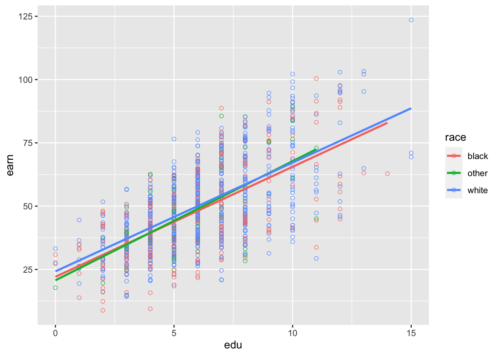

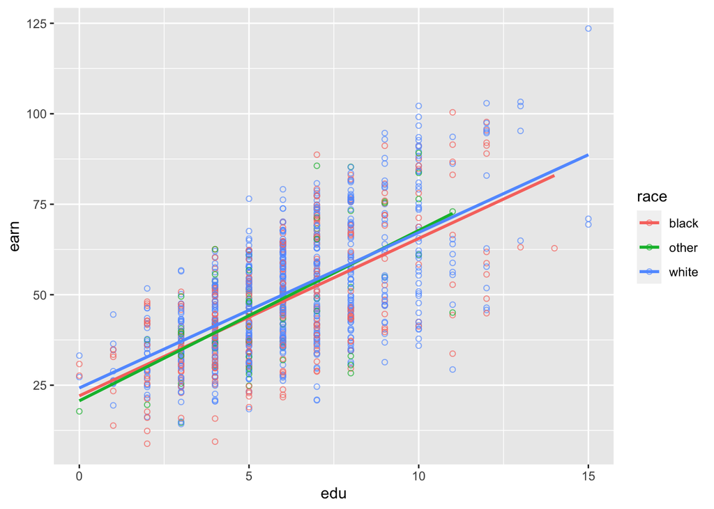

```r
# Scatterplot of earnings and education, grouped by gender
earnings_df %>%
  ggplot(aes(x = edu, y = earn, color = race)) +
  geom_point(shape = 1, alpha = 0.7) +
  geom_smooth(method = "lm", se = F)
```

```r
#ggsave("scatterplot_race.png", height = 5, width = 7)
```

### Part 2 Exercise 2

Now, estimate the following models and display your model results in a single table using `stargazer(m_1, m_2, ..., m_n, type="text")`. Post a screenshot of your table on Slack.

1. Model 1: earn ~ age (baseline)
2. Model 2: earn ~ age + edu
3. Model 3: earn ~ age + edu + female
4. Model 4: earn ~ age + edu + female + race
5. Model 5: earn ~ age + edu + female + race + edu*female

```r
# Nested Models

m1 <- lm(earn ~ age_recode,
         data = earnings_df)

m2 <- lm(earn ~ age_recode + edu,
         data = earnings_df)

m3 <- lm(earn ~ age_recode + edu + female,
         data = earnings_df)

m4 <- lm(earn ~ age_recode + edu + female + black + other,
         data = earnings_df)

m5 <- lm(earn ~ age_recode + edu + female + black + other + edu*female,
         data = earnings_df)

stargazer(m1, m2, m3, m4, m5, type="text", omit.stat=c("ser", "f"))
```

```
##
## ================================================================
##                              Dependent variable:
##              ---------------------------------------------------
##                                     earn
##                 (1)       (2)       (3)        (4)        (5)
## ----------------------------------------------------------------
## age_recode   0.134***  0.132***   0.160***   0.158***  0.156***
##               (0.042)   (0.033)   (0.022)    (0.022)    (0.019)
##
## edu                    4.314***   4.500***   4.477***  6.083***
##                         (0.171)   (0.112)    (0.112)    (0.143)
##
## female                           -20.528*** -20.572***  -1.571
##                                   (0.568)    (0.565)    (1.311)
##
## black                                       -2.307***  -2.385***
##                                              (0.623)    (0.557)
##
## other                                         -0.767    -0.946
##                                              (1.137)    (1.017)
##
## edu:female                                             -3.128***
##                                                         (0.199)
##
## Constant     43.888*** 17.786*** 25.439***  26.429***  16.974***
##               (1.917)   (1.817)   (1.207)    (1.230)    (1.254)
##
## ----------------------------------------------------------------
## Observations    980       980       980        980        980
## R2             0.010     0.400     0.744      0.747      0.798
## Adjusted R2    0.009     0.399     0.743      0.746      0.797
## ================================================================
## Note:                                *p<0.1; **p<0.05; ***p<0.01
```

### Part 3 Exercise

1. In Model 5, holding other variables constant, what will be the predicted difference in estimated mean earnings for a white man and a white women?
2. Holding other variables constant, what will be the predicted difference in estimated mean earnings for a white women and a black women?
3. Holding other variables constant, what will be the predicted difference in estimated mean earnings for a white man and a black women?

Answer:

Q1: For a white man:

$$\Delta\hat{Earnings}_{\text{wh,m}} = 6.083\cdot \text{edu} -1.571\cdot 0 - 3.128\cdot\text{edu }\cdot0 \\ = 6.083\cdot \text{edu}$$

For a white woman:

$$\Delta\hat{Earnings}_{\text{wh,w}} = 6.083\cdot \text{edu} -1.571\cdot 1 - 3.128\cdot\text{edu }\cdot1 \\ = 6.083\cdot \text{edu} -1.571 - 3.128\cdot\text{edu }$$

Thus the difference in $\Delta\hat{Earnings}$ between a white man and a white woman: $-1.571 - 3.128\cdot\text{edu }$

Q2: For a white woman, it’s demonstrated above. For a black woman:

$$\Delta\hat{Earnings}_{\text{bl,w}} = 6.083\cdot \text{edu} - 2.385\cdot1 -1.571\cdot 1 - 3.128\cdot\text{edu }\cdot1 \\ = 6.083\cdot \text{edu} - 2.385 -1.571 - 3.128\cdot\text{edu }$$

Thus the difference in $\Delta\hat{Earnings}$ between a white woman and a black woman is:$- 2.385$

Q3: From the equations above, we know the difference between $\Delta\hat{Earnings}_{\text{wh,m}}$ and $\Delta\hat{Earnings}_{\text{bl,w}}$ is $- 2.385 -1.571 - 3.128\cdot\text{edu } = -3.956 - 3.128\cdot\text{edu }$

### Part 4 Exercise

Plot the effect of `age` on `earn` according to Model 5. Post your plot on Slack.

```r
# first, we create a dataframe with all predictor variables
# with only the key IV varies
pred_age <- tibble(age_recode = seq(20, 65, 3)) %>%
  mutate(edu = mean(earnings_df$edu, na.rm = T),
         female = mean(earnings_df$female, na.rm = T),
         black = mean(earnings_df$black, na.rm = T),
         other = mean(earnings_df$other, na.rm = T))

# use `predict` to predict the Y
predicted_earning_byage <- predict(m5,                      # the model you are using
                             pred_age,                # the df you use for predicting
                             interval = "confidence", # set CI
                             level = 0.95)

# bind the columns
pred_age_result <- cbind(pred_age, predicted_earning_byage)

# check df
head(pred_age_result, 10) %>% kbl("html") %>% kable_classic_2(full_width = F)
```

| age_recode | edu | female | black | other | fit | lwr | upr |
| --- | --- | --- | --- | --- | --- | --- | --- |
| 20 | 6.084 | 0.485 | 0.306 | 0.068 | 46.31507 | 45.30736 | 47.32278 |
| 23 | 6.084 | 0.485 | 0.306 | 0.068 | 46.78325 | 45.87250 | 47.69400 |
| 26 | 6.084 | 0.485 | 0.306 | 0.068 | 47.25143 | 46.43344 | 48.06941 |
| 29 | 6.084 | 0.485 | 0.306 | 0.068 | 47.71960 | 46.98861 | 48.45060 |
| 32 | 6.084 | 0.485 | 0.306 | 0.068 | 48.18778 | 47.53566 | 48.83990 |
| 35 | 6.084 | 0.485 | 0.306 | 0.068 | 48.65596 | 48.07133 | 49.24059 |
| 38 | 6.084 | 0.485 | 0.306 | 0.068 | 49.12414 | 48.59124 | 49.65703 |
| 41 | 6.084 | 0.485 | 0.306 | 0.068 | 49.59232 | 49.09053 | 50.09410 |
| 44 | 6.084 | 0.485 | 0.306 | 0.068 | 50.06049 | 49.56527 | 50.55571 |
| 47 | 6.084 | 0.485 | 0.306 | 0.068 | 50.52867 | 50.01454 | 51.04281 |

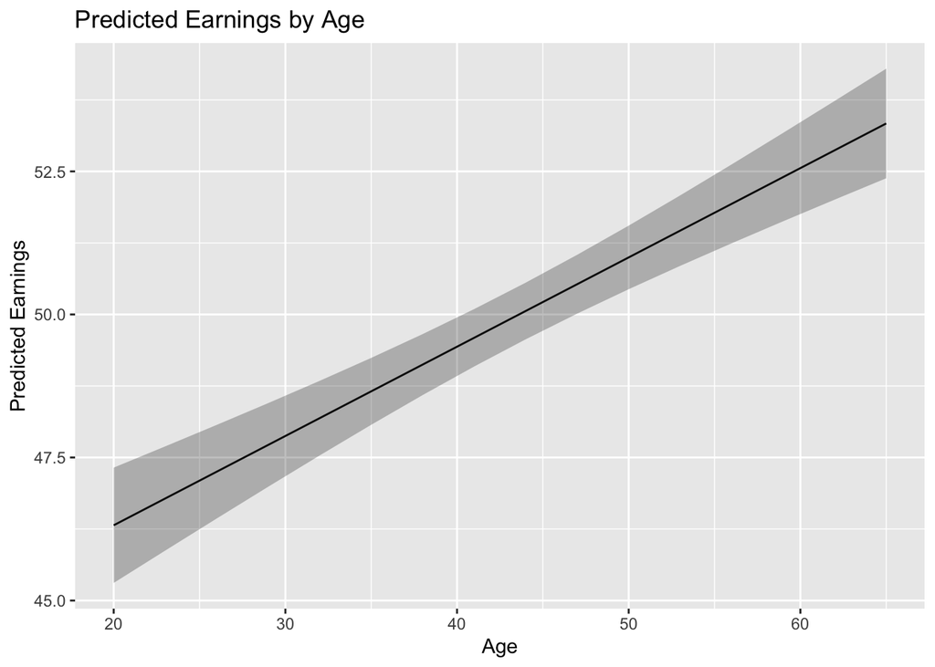

```r
# Plot
pred_age_result %>%
  ggplot(aes(x = age_recode, y = fit)) +
  geom_line() +
  geom_ribbon(aes(ymin = lwr, ymax = upr), alpha = 0.3) +   # add 95% CI
  labs(x = "Age",
       y = "Predicted Earnings") +
  ggtitle("Predicted Earnings by Age")
```